> **Tip**: Welcome to the Investigate a Dataset project! You will find tips in quoted sections like this to help organize your approach to your investigation. Before submitting your project, it will be a good idea to go back through your report and remove these sections to make the presentation of your work as tidy as possible. First things first, you might want to double-click this Markdown cell and change the title so that it reflects your dataset and investigation.

# Project: TMDB-movies data analysis

- Introduction
- Data Wrangling
- Exploratory Data Analysis
- Conclusions

## Introduction

> I chose this dataset because I find it may answer intersting questions regarding the movies that has high revenues and alot about movies in general, it contain enough features which help answering many questions about movies industry.  
> Q1) Does higher budget movies mean higher profit ?  
> Q2) How year time of the releasing date may be related to revenues and profits ?  
> Q3) Does longer movies correlated to movie profits ?  
> Q4) Which production companies achieve highest profits  
> Q5) Which directors have the highest vote rate  
> Q6) What are the most popular genres ?

```python
#importing pandas, numby and plotly
import pandas as pd
import numpy as np
import matplotlib.pyplot as plt
import seaborn as sns
from sklearn.preprocessing import MinMaxScaler
from datetime import datetime
%matplotlib inline
```

## Data Wrangling

Lets start by exploring the dataset step by step to discover the gaps in the data that could be fixed or ignored

### General Properties

```python
#Loading data
df = pd.read_csv('tmdb-movies.csv', encoding='utf-8')

df[df['revenue'] == 0]
```

|  | id | imdb_id | popularity | budget | revenue | original_title | cast | homepage | director | tagline | ... | overview | runtime | genres | production_companies | release_date | vote_count | vote_average | release_year | budget_adj | revenue_adj |
| --- | --- | --- | --- | --- | --- | --- | --- | --- | --- | --- | --- | --- | --- | --- | --- | --- | --- | --- | --- | --- | --- |
| 48 | 265208 | tt2231253 | 2.932340 | 30000000 | 0 | Wild Card | Jason Statham\|Michael Angarano\|Milo Ventimigli... | NaN | Simon West | Never bet against a man with a killer hand. | ... | When a Las Vegas bodyguard with lethal skills ... | 92 | Thriller\|Crime\|Drama | Current Entertainment\|Lionsgate\|Sierra / Affin... | 1/14/15 | 481 | 5.3 | 2015 | 2.759999e+07 | 0.0 |
| 67 | 334074 | tt3247714 | 2.331636 | 20000000 | 0 | Survivor | Pierce Brosnan\|Milla Jovovich\|Dylan McDermott\|... | http://survivormovie.com/ | James McTeigue | His Next Target is Now Hunting Him | ... | A Foreign Service Officer in London tries to p... | 96 | Crime\|Thriller\|Action | Nu Image Films\|Winkler Films\|Millennium Films\|... | 5/21/15 | 280 | 5.4 | 2015 | 1.839999e+07 | 0.0 |
| 74 | 347096 | tt3478232 | 2.165433 | 0 | 0 | Mythica: The Darkspore | Melanie Stone\|Kevin Sorbo\|Adam Johnson\|Jake St... | http://www.mythicamovie.com/#!blank/wufvh | Anne K. Black | NaN | ... | When Teelaâ€™s sister is murdered and a powerf... | 108 | Action\|Adventure\|Fantasy | Arrowstorm Entertainment | 6/24/15 | 27 | 5.1 | 2015 | 0.000000e+00 | 0.0 |
| 75 | 308369 | tt2582496 | 2.141506 | 0 | 0 | Me and Earl and the Dying Girl | Thomas Mann\|RJ Cyler\|Olivia Cooke\|Connie Britt... | http://www.foxsearchlight.com/meandearlandthed... | Alfonso Gomez-Rejon | A Little Friendship Never Killed Anyone. | ... | Greg is coasting through senior year of high s... | 105 | Comedy\|Drama | Indian Paintbrush | 6/12/15 | 569 | 7.7 | 2015 | 0.000000e+00 | 0.0 |
| 92 | 370687 | tt3608646 | 1.876037 | 0 | 0 | Mythica: The Necromancer | Melanie Stone\|Adam Johnson\|Kevin Sorbo\|Nicola ... | http://www.mythicamovie.com/#!blank/y9ake | A. Todd Smith | NaN | ... | Mallister takes Thane prisoner and forces Mare... | 0 | Fantasy\|Action\|Adventure | Arrowstorm Entertainment\|Camera 40 Productions... | 12/19/15 | 11 | 5.4 | 2015 | 0.000000e+00 | 0.0 |
| ... | ... | ... | ... | ... | ... | ... | ... | ... | ... | ... | ... | ... | ... | ... | ... | ... | ... | ... | ... | ... | ... |
| 10861 | 21 | tt0060371 | 0.080598 | 0 | 0 | The Endless Summer | Michael Hynson\|Robert August\|Lord 'Tally Ho' B... | NaN | Bruce Brown | NaN | ... | The Endless Summer, by Bruce Brown, is one of ... | 95 | Documentary | Bruce Brown Films | 6/15/66 | 11 | 7.4 | 1966 | 0.000000e+00 | 0.0 |
| 10862 | 20379 | tt0060472 | 0.065543 | 0 | 0 | Grand Prix | James Garner\|Eva Marie Saint\|Yves Montand\|Tosh... | NaN | John Frankenheimer | Cinerama sweeps YOU into a drama of speed and ... | ... | Grand Prix driver Pete Aron is fired by his te... | 176 | Action\|Adventure\|Drama | Cherokee Productions\|Joel Productions\|Douglas ... | 12/21/66 | 20 | 5.7 | 1966 | 0.000000e+00 | 0.0 |
| 10863 | 39768 | tt0060161 | 0.065141 | 0 | 0 | Beregis Avtomobilya | Innokentiy Smoktunovskiy\|Oleg Efremov\|Georgi Z... | NaN | Eldar Ryazanov | NaN | ... | An insurance agent who moonlights as a carthie... | 94 | Mystery\|Comedy | Mosfilm | 1/1/66 | 11 | 6.5 | 1966 | 0.000000e+00 | 0.0 |
| 10864 | 21449 | tt0061177 | 0.064317 | 0 | 0 | What's Up, Tiger Lily? | Tatsuya Mihashi\|Akiko Wakabayashi\|Mie Hama\|Joh... | NaN | Woody Allen | WOODY ALLEN STRIKES BACK! | ... | In comic Woody Allen's film debut, he took the... | 80 | Action\|Comedy | Benedict Pictures Corp. | 11/2/66 | 22 | 5.4 | 1966 | 0.000000e+00 | 0.0 |
| 10865 | 22293 | tt0060666 | 0.035919 | 19000 | 0 | Manos: The Hands of Fate | Harold P. Warren\|Tom Neyman\|John Reynolds\|Dian... | NaN | Harold P. Warren | It's Shocking! It's Beyond Your Imagination! | ... | A family gets lost on the road and stumbles up... | 74 | Horror | Norm-Iris | 11/15/66 | 15 | 1.5 | 1966 | 1.276423e+05 | 0.0 |

6016 rows × 21 columns

```python
#Checking for number of rows and columns
df.shape
```

```
(10866, 21)
```

# Data cleaning

1) we see here some columns like release_year, release_date are represented in the wrong dtype which may be an issue for us during running some pandas operations.  
2) some columns lie overview, keywords, tagline, id budget & revenue(as we have budget_adj and rev_adj) may not be useful in answering our main Questions, thus we better drop them.  
3) we want to handle the big integers in the budget_adj and revenues_adj, and we may try to scaling the popularity column so they don't be an issue while visualizing data

```python
#Checking for missing data and data types
df.info()
```

```
<class 'pandas.core.frame.DataFrame'>
RangeIndex: 10866 entries, 0 to 10865
Data columns (total 21 columns):
id                      10866 non-null int64
imdb_id                 10856 non-null object
popularity              10866 non-null float64
budget                  10866 non-null int64
revenue                 10866 non-null int64
original_title          10866 non-null object
cast                    10790 non-null object
homepage                2936 non-null object
director                10822 non-null object
tagline                 8042 non-null object
keywords                9373 non-null object
overview                10862 non-null object
runtime                 10866 non-null int64
genres                  10843 non-null object
production_companies    9836 non-null object
release_date            10866 non-null object
vote_count              10866 non-null int64
vote_average            10866 non-null float64
release_year            10866 non-null int64
budget_adj              10866 non-null float64
revenue_adj             10866 non-null float64
dtypes: float64(4), int64(6), object(11)
memory usage: 1.7+ MB
```

Now we can drop this cols and see the dataset

```python
#dropping useless columns
df.drop(['id', 'homepage', 'tagline', 'keywords', 'overview', 'budget', 'revenue'], axis=1, inplace=True)
df.head()
```

|  | imdb_id | popularity | original_title | cast | director | runtime | genres | production_companies | release_date | vote_count | vote_average | release_year | budget_adj | revenue_adj |
| --- | --- | --- | --- | --- | --- | --- | --- | --- | --- | --- | --- | --- | --- | --- |
| 0 | tt0369610 | 32.985763 | Jurassic World | Chris Pratt\|Bryce Dallas Howard\|Irrfan Khan\|Vi... | Colin Trevorrow | 124 | Action\|Adventure\|Science Fiction\|Thriller | Universal Studios\|Amblin Entertainment\|Legenda... | 6/9/15 | 5562 | 6.5 | 2015 | 1.379999e+08 | 1.392446e+09 |
| 1 | tt1392190 | 28.419936 | Mad Max: Fury Road | Tom Hardy\|Charlize Theron\|Hugh Keays-Byrne\|Nic... | George Miller | 120 | Action\|Adventure\|Science Fiction\|Thriller | Village Roadshow Pictures\|Kennedy Miller Produ... | 5/13/15 | 6185 | 7.1 | 2015 | 1.379999e+08 | 3.481613e+08 |
| 2 | tt2908446 | 13.112507 | Insurgent | Shailene Woodley\|Theo James\|Kate Winslet\|Ansel... | Robert Schwentke | 119 | Adventure\|Science Fiction\|Thriller | Summit Entertainment\|Mandeville Films\|Red Wago... | 3/18/15 | 2480 | 6.3 | 2015 | 1.012000e+08 | 2.716190e+08 |
| 3 | tt2488496 | 11.173104 | Star Wars: The Force Awakens | Harrison Ford\|Mark Hamill\|Carrie Fisher\|Adam D... | J.J. Abrams | 136 | Action\|Adventure\|Science Fiction\|Fantasy | Lucasfilm\|Truenorth Productions\|Bad Robot | 12/15/15 | 5292 | 7.5 | 2015 | 1.839999e+08 | 1.902723e+09 |
| 4 | tt2820852 | 9.335014 | Furious 7 | Vin Diesel\|Paul Walker\|Jason Statham\|Michelle ... | James Wan | 137 | Action\|Crime\|Thriller | Universal Pictures\|Original Film\|Media Rights ... | 4/1/15 | 2947 | 7.3 | 2015 | 1.747999e+08 | 1.385749e+09 |

```python
# Now lets handle the column types
#Converting the date type in the dataset into date_time
df['release_date'] = pd.to_datetime(df['release_date'])
df.dtypes
```

```
imdb_id                         object
popularity                     float64
original_title                  object
cast                            object
director                        object
runtime                          int64
genres                          object
production_companies            object
release_date            datetime64[ns]
vote_count                       int64
vote_average                   float64
release_year                     int64
budget_adj                     float64
revenue_adj                    float64
dtype: object
```

The best way to deal with the popularity column is to turn intt a rate value (normalize it), as the min value of it is 0.015 and the max value is 34, so it will be an issue in analysing the data

```python
# Normalizing popularity column
df['popularity'] =  MinMaxScaler().fit_transform(np.array(df['popularity']).reshape(-1,1))
```

# Handling missing data

2) The check for missing data above may have been a little bit misleading regarding important numerical columns like budget revnues, budg_adj, and rev_adj because almost half of the rows have zeroes in these columns which may affect our analysis when analyzing the means of this values later, thus we better handle that by replacing these zerores with nans and not drop all these rows.

```python
# Dropping rows whith missing value
df = df.dropna(subset=('cast', 'production_companies', 'genres'))

#Checking for null values again
df.shape
```

```
(9792, 14)
```

```python
# Replacing zeroes in the budget_adj and rev_adj columns by nans
df['budget_adj'].replace(0, np.nan, inplace=True)
df['revenue_adj'].replace(0, np.nan, inplace=True)
```

```python
# Now lets handle the budjet and revenue column we want them to be represented im Million$ Thus we divide them by 1000000
df['budget_adj'] = round(df['budget_adj']/1000000, 2)
df['revenue_adj'] = round(df['revenue_adj']/1000000, 2)

df.rename(columns = {'budget_adj':'budget_adj_m', 'revenue_adj':'revenue_adj_m'}, inplace = True)
```

# Adding new columns

So far good, we cleaned our data now we want to add some features(columns) that will help in answering our questions so we add:  
1) column for profit (rev - budget)  
2) column for month (by extracting it from date)  
3) column for season (by extracting it from date)[1] got it from stackoverflow  
1.[https://stackoverflow.com/questions/60285557/extract-seasons-from-datetime-pandas]

```python
#Adding profit column
df['profit_m'] = df['revenue_adj_m'] - df['budget_adj_m']
#Adding month column
df['month'] = df['release_date'].dt.month
#Adding season_name column
df['season'] = (df['release_date'].dt.month%12 + 3)//3
seasons = {
             1: 'Winter',
             2: 'Spring',
             3: 'Summer',
             4: 'Autumn'
}

df['season_name'] = df['season'].map(seasons)

#dropping season as we made that column to be able to put rh season name

df.drop('season', axis=1, inplace = True)
```

```python
# Lets Display our data one last time before doing the analysis
```

[output not shown]

# Functions

We have one more issue in 3 columns(df[cast], df[genres], df[production companies] in our dataset that require us to do the analysis in a different way.

1) We have data in these columns in form of lists(groups) which make it hard for us to do the analysis regarding each actor and each genre and each company alone thus we create a function that takes each column alone and return a dictionary with the unique values of that column as keys and and the mean or sum value with the respect of the get_val_col in input for as value

in other words the function just get the sum or avg values of revenues and profits in respect of each single actor, genre, production company

2) The other function plots the visualizations based on input

```python
def lst_elements_calculator( col_name, get_value_col, calculate):

    """ This function takes 2 cols as input including a column with many categorical vals
    and return a dataframe of unique values in all that column with sum or avg values for it determined
    input column"""

    df_no_nans = df[df[col_name].notnull()]

    #spliting each name val from the col_name
    split_of_cell = [name.split('|') for name in df[df[col_name].notnull()][col_name].values]
    #merging all unique elements from all lists in one big list
    list_all_unique_elements = set(sum(np.array(split_of_cell), []))
    #declaring an empty dictionary
    data = {}
    #This loop iterate over the list which contains all the unique elements, assign each element as a key
    #in the dict and filter the dataframe based on the rows containing that element in the text for col_name
    #and assign the values of the filtered dataframe in get_value_col as the value of the dict key(name)
    for name in list_all_unique_elements:
        #We use try except statement here to avoid an error that happen at 1 row that contain '/'
        #Thus don't excpect that this will cause any data missing
        try:
            data[name] = (df_no_nans[df_no_nans[col_name].str.contains(name)][get_value_col].values)

        except:
            data[name] = (df_no_nans[df_no_nans[col_name].str.contains(name[:-1])][get_value_col].values)

        # The calculate argument could be mean or sum if its mean the dictionary value for each key is set
        # to be the mean of values of elements if its sum then it becoms the sum
        try:
            if (calculate == 'mean'):
                data[name] = float(sum(data[name]) / len(data[name]))
            elif (calculate == 'sum'):
                data[name] = float(round(sum(data[name]), 4))
        except ZeroDivisionError:
            pass
    #converting the dict into a df and returning it with the means or sums as a col
    data_df = pd.DataFrame(list(data.items()),columns = [col_name, get_value_col+'_'+ calculate])
    return data_df
```

```python
df.describe()
```

|  | popularity | runtime | vote_count | vote_average | release_year | budget_adj_m | revenue_adj_m | profit_m | month |
| --- | --- | --- | --- | --- | --- | --- | --- | --- | --- |
| count | 9792.000000 | 9792.000000 | 9792.000000 | 9792.000000 | 9792.000000 | 5025.000000 | 4752.000000 | 3807.000000 | 9792.000000 |
| mean | 0.021027 | 102.860703 | 238.873060 | 5.964890 | 2000.893689 | 37.765381 | 117.326343 | 93.940909 | 6.874898 |
| std | 0.031413 | 27.943064 | 602.474229 | 0.913438 | 13.036667 | 42.201510 | 200.248758 | 194.997175 | 3.412411 |
| min | 0.000004 | 0.000000 | 10.000000 | 1.500000 | 1960.000000 | 0.000000 | 0.000000 | -413.910000 | 1.000000 |
| 25% | 0.007020 | 90.000000 | 18.000000 | 5.400000 | 1994.000000 | 8.860000 | 11.637500 | -1.420000 | 4.000000 |
| 50% | 0.012705 | 100.000000 | 46.000000 | 6.000000 | 2005.000000 | 23.730000 | 45.725000 | 28.490000 | 7.000000 |
| 75% | 0.023492 | 112.000000 | 173.000000 | 6.600000 | 2011.000000 | 50.820000 | 134.862500 | 108.975000 | 10.000000 |
| max | 1.000000 | 877.000000 | 9767.000000 | 8.700000 | 2015.000000 | 425.000000 | 2827.120000 | 2750.130000 | 12.000000 |

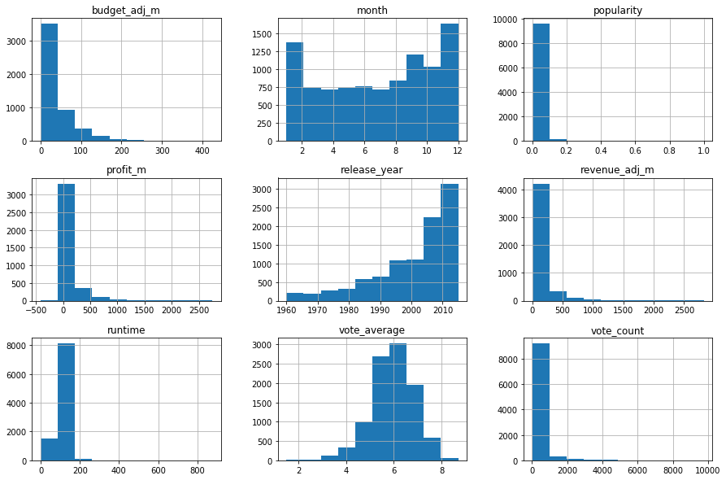

```python
# Displaying a histogram
df.hist(figsize=(15,10));
```

```python
# Lets see how data features are correlated to each other and represent this relation by a corr matrix
df.corr()
```

|  | popularity | runtime | vote_count | vote_average | release_year | budget_adj_m | revenue_adj_m | profit_m | month |
| --- | --- | --- | --- | --- | --- | --- | --- | --- | --- |
| popularity | 1.000000 | 0.156933 | 0.803001 | 0.237900 | 0.110231 | 0.428986 | 0.558886 | 0.515191 | 0.037551 |
| runtime | 0.156933 | 1.000000 | 0.184480 | 0.190559 | -0.134154 | 0.325834 | 0.262149 | 0.234188 | 0.064066 |
| vote_count | 0.803001 | 0.184480 | 1.000000 | 0.278894 | 0.124172 | 0.519411 | 0.664617 | 0.612846 | 0.022810 |
| vote_average | 0.237900 | 0.190559 | 0.278894 | 1.000000 | -0.138642 | 0.107098 | 0.245289 | 0.290381 | 0.074413 |
| release_year | 0.110231 | -0.134154 | 0.124172 | -0.138642 | 1.000000 | 0.045508 | -0.095836 | -0.131620 | -0.052413 |
| budget_adj_m | 0.428986 | 0.325834 | 0.519411 | 0.107098 | 0.045508 | 1.000000 | 0.568053 | 0.401879 | 0.068571 |
| revenue_adj_m | 0.558886 | 0.262149 | 0.664617 | 0.245289 | -0.095836 | 0.568053 | 1.000000 | 0.981896 | 0.059441 |
| profit_m | 0.515191 | 0.234188 | 0.612846 | 0.290381 | -0.131620 | 0.401879 | 0.981896 | 1.000000 | 0.048403 |
| month | 0.037551 | 0.064066 | 0.022810 | 0.074413 | -0.052413 | 0.068571 | 0.059441 | 0.048403 | 1.000000 |

# Scatterplot

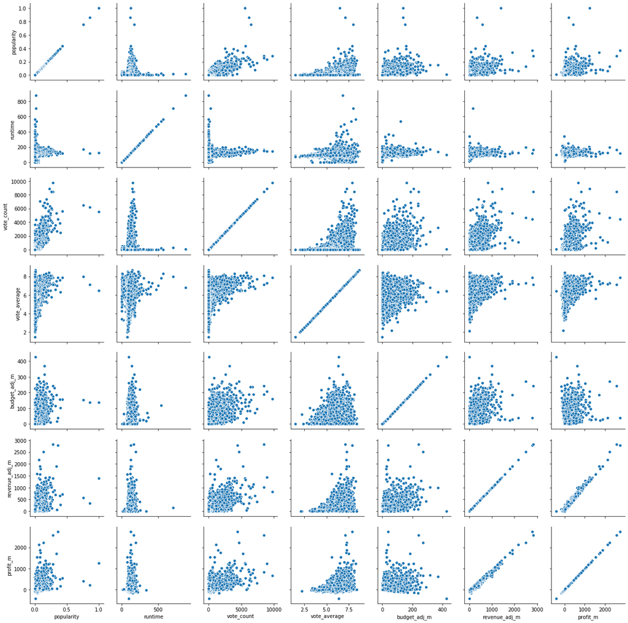

```python
# lets plot a scatter plot to see how numerical variables correlated to each other
g = sns.PairGrid(df[['popularity', 'runtime', 'vote_count', 'vote_average', 'budget_adj_m', 'revenue_adj_m', 'profit_m']])
g.map(sns.scatterplot);
```

Now lets do some real analysis and compare the revenues of the movies in respect to the year season

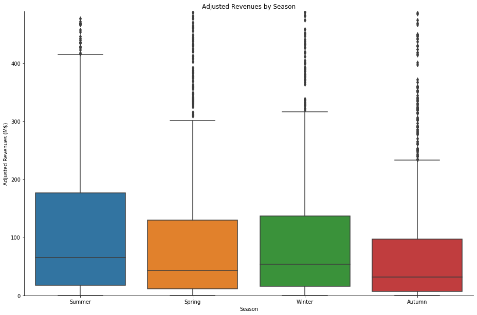

```python
#ploting boxplot
ax = sns.catplot(x="season_name", y="revenue_adj_m", kind="box", data=df)
ax.fig.set_size_inches(15,9);
ax.set(title = 'Adjusted Revenues by Season')
ax.set(xlabel='Season')
ax.set(ylabel='Adjusted Revenues (M$)')
ax.set(ylim=(0,df.revenue_adj_m.quantile(0.95)));
```